# Risk Factor Analysis

## Outcome Variable

**Outcome Variable:** stunted

## Predictor Variables

**Intervention Variable:** predfeed3

**Adjustment Set:**

- arm
- sex
- month
- brthmon
- W_mage
- meducyrs
- feducyrs
- hhwealth_quart
- hfoodsec
- W_mhtcm
- vagbrth
- W_gagebrth
- W_birthwt
- W_birthlen
- W_nrooms
- W_nchldlt5
- W_parity
- impfloor
- impsan
- safeh20
- delta_W_mage
- delta_meducyrs
- delta_feducyrs
- delta_hhwealth_quart
- delta_hfoodsec
- delta_W_mhtcm
- delta_vagbrth
- delta_W_gagebrth
- delta_W_birthwt
- delta_W_birthlen
- delta_W_nrooms
- delta_W_nchldlt5
- delta_W_parity
- delta_impfloor
- delta_impsan
- delta_safeh20

## Stratifying Variables

The analysis was stratified on these variable(s):

- agecat
- studyid
- country

## Data Summary

| agecat | studyid | country | predfeed3 | stunted | n_cell | n |
| --- | --- | --- | --- | --- | --- | --- |
| Birth | ki0047075b-MAL-ED | BANGLADESH | 1 | 0 | 169 | 240 |
| Birth | ki0047075b-MAL-ED | BANGLADESH | 1 | 1 | 36 | 240 |
| Birth | ki0047075b-MAL-ED | BANGLADESH | 0 | 0 | 30 | 240 |
| Birth | ki0047075b-MAL-ED | BANGLADESH | 0 | 1 | 5 | 240 |
| Birth | ki0047075b-MAL-ED | BRAZIL | 1 | 0 | 93 | 185 |
| Birth | ki0047075b-MAL-ED | BRAZIL | 1 | 1 | 8 | 185 |
| Birth | ki0047075b-MAL-ED | BRAZIL | 0 | 0 | 73 | 185 |
| Birth | ki0047075b-MAL-ED | BRAZIL | 0 | 1 | 11 | 185 |
| Birth | ki0047075b-MAL-ED | INDIA | 1 | 0 | 130 | 196 |
| Birth | ki0047075b-MAL-ED | INDIA | 1 | 1 | 22 | 196 |
| Birth | ki0047075b-MAL-ED | INDIA | 0 | 0 | 35 | 196 |
| Birth | ki0047075b-MAL-ED | INDIA | 0 | 1 | 9 | 196 |
| Birth | ki0047075b-MAL-ED | NEPAL | 1 | 0 | 91 | 171 |
| Birth | ki0047075b-MAL-ED | NEPAL | 1 | 1 | 8 | 171 |
| Birth | ki0047075b-MAL-ED | NEPAL | 0 | 0 | 62 | 171 |
| Birth | ki0047075b-MAL-ED | NEPAL | 0 | 1 | 10 | 171 |
| Birth | ki0047075b-MAL-ED | PERU | 1 | 0 | 160 | 272 |
| Birth | ki0047075b-MAL-ED | PERU | 1 | 1 | 23 | 272 |
| Birth | ki0047075b-MAL-ED | PERU | 0 | 0 | 80 | 272 |
| Birth | ki0047075b-MAL-ED | PERU | 0 | 1 | 9 | 272 |
| Birth | ki0047075b-MAL-ED | SOUTH AFRICA | 1 | 0 | 80 | 233 |
| Birth | ki0047075b-MAL-ED | SOUTH AFRICA | 1 | 1 | 7 | 233 |
| Birth | ki0047075b-MAL-ED | SOUTH AFRICA | 0 | 0 | 129 | 233 |
| Birth | ki0047075b-MAL-ED | SOUTH AFRICA | 0 | 1 | 17 | 233 |
| Birth | ki0047075b-MAL-ED | TANZANIA, UNITED REPUBLIC OF | 1 | 0 | 45 | 119 |
| Birth | ki0047075b-MAL-ED | TANZANIA, UNITED REPUBLIC OF | 1 | 1 | 5 | 119 |
| Birth | ki0047075b-MAL-ED | TANZANIA, UNITED REPUBLIC OF | 0 | 0 | 56 | 119 |
| Birth | ki0047075b-MAL-ED | TANZANIA, UNITED REPUBLIC OF | 0 | 1 | 13 | 119 |
| Birth | ki1000109-EE | PAKISTAN | 1 | 0 | 1 | 2 |
| Birth | ki1000109-EE | PAKISTAN | 1 | 1 | 1 | 2 |

[output cut: 94 more lines]

The following strata were considered:

- agecat: 24 months, studyid: ki0047075b-MAL-ED, country: BANGLADESH
- agecat: 24 months, studyid: ki0047075b-MAL-ED, country: BRAZIL
- agecat: 24 months, studyid: ki0047075b-MAL-ED, country: INDIA
- agecat: 24 months, studyid: ki0047075b-MAL-ED, country: NEPAL
- agecat: 24 months, studyid: ki0047075b-MAL-ED, country: PERU
- agecat: 24 months, studyid: ki0047075b-MAL-ED, country: SOUTH AFRICA
- agecat: 24 months, studyid: ki0047075b-MAL-ED, country: TANZANIA, UNITED REPUBLIC OF
- agecat: 24 months, studyid: ki1113344-GMS-Nepal, country: NEPAL
- agecat: 24 months, studyid: kiGH5241-JiVitA-3, country: BANGLADESH
- agecat: 24 months, studyid: kiGH5241-JiVitA-4, country: BANGLADESH
- agecat: 6 months, studyid: ki0047075b-MAL-ED, country: BANGLADESH
- agecat: 6 months, studyid: ki0047075b-MAL-ED, country: BRAZIL
- agecat: 6 months, studyid: ki0047075b-MAL-ED, country: INDIA
- agecat: 6 months, studyid: ki0047075b-MAL-ED, country: NEPAL
- agecat: 6 months, studyid: ki0047075b-MAL-ED, country: PERU
- agecat: 6 months, studyid: ki0047075b-MAL-ED, country: SOUTH AFRICA
- agecat: 6 months, studyid: ki0047075b-MAL-ED, country: TANZANIA, UNITED REPUBLIC OF
- agecat: 6 months, studyid: ki1000109-EE, country: PAKISTAN
- agecat: 6 months, studyid: ki1113344-GMS-Nepal, country: NEPAL
- agecat: 6 months, studyid: kiGH5241-JiVitA-3, country: BANGLADESH
- agecat: 6 months, studyid: kiGH5241-JiVitA-4, country: BANGLADESH
- agecat: Birth, studyid: ki0047075b-MAL-ED, country: BANGLADESH
- agecat: Birth, studyid: ki0047075b-MAL-ED, country: BRAZIL
- agecat: Birth, studyid: ki0047075b-MAL-ED, country: INDIA
- agecat: Birth, studyid: ki0047075b-MAL-ED, country: NEPAL
- agecat: Birth, studyid: ki0047075b-MAL-ED, country: PERU
- agecat: Birth, studyid: ki0047075b-MAL-ED, country: SOUTH AFRICA
- agecat: Birth, studyid: ki0047075b-MAL-ED, country: TANZANIA, UNITED REPUBLIC OF
- agecat: Birth, studyid: ki1000109-EE, country: PAKISTAN
- agecat: Birth, studyid: kiGH5241-JiVitA-3, country: BANGLADESH
- agecat: Birth, studyid: kiGH5241-JiVitA-4, country: BANGLADESH

### Dropped Strata

Some strata were dropped due to rare outcomes:

- agecat: Birth, studyid: ki1000109-EE, country: PAKISTAN
- agecat: Birth, studyid: kiGH5241-JiVitA-4, country: BANGLADESH
- agecat: 6 months, studyid: ki0047075b-MAL-ED, country: BRAZIL
- agecat: 24 months, studyid: ki0047075b-MAL-ED, country: BRAZIL

## Methods Detail

We’re interested in the causal parameters $E[Y_a]$ for all values of $a \in \mathcal{A}$. These parameters represent the mean outcome if, possibly contrary to fact, we intervened to set all units to have $A=a$. Under the randomization and positivity assumptions, these are identified by the statistical parameters $\psi_a=E_W[E_{Y|A,W}(Y|A=a,W)]$. In addition, we’re interested in the mean of $Y$, $E[Y]$ under no intervention (the observed mean). We will estimate these parameters by using SuperLearner to fit the relevant likelihood factors – $E_{Y|A,W}(Y|A=a,W)$ and $p(A=a|W)$, and then updating our likelihood fit using a joint TMLE.

For unadjusted analyses ($W=\{\}$), initial likelihoods were estimated using Lrnr_glm to estimate the simple $E(Y|A)$ and Lrnr_mean to estimate $p(A)$. For adjusted analyses, a small library containing Lrnr_glmnet, Lrnr_xgboost, and Lrnr_mean was used.

Having estimated these parameters, we will then use the delta method to estimate relative risks and attributable risks relative to a prespecified baseline level of $A$.

# Results Detail

## Results Plots

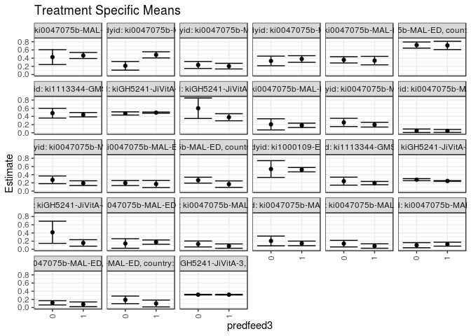

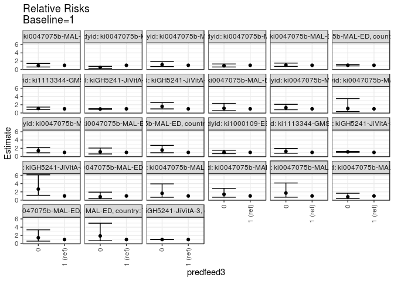

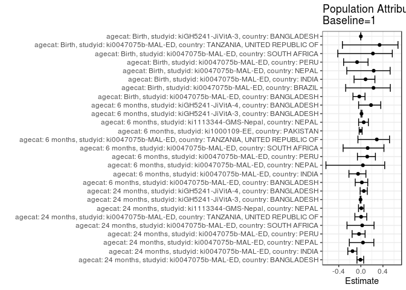

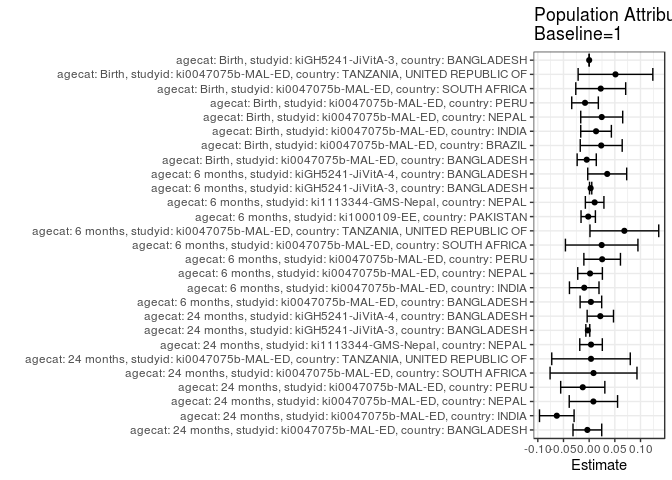

## Results Table

### Parameter: TSM

| agecat | studyid | country | intervention_level | baseline_level | estimate | ci_lower | ci_upper |
| --- | --- | --- | --- | --- | --- | --- | --- |
| Birth | ki0047075b-MAL-ED | BANGLADESH | 1 | NA | 0.1756098 | 0.1234160 | 0.2278035 |
| Birth | ki0047075b-MAL-ED | BANGLADESH | 0 | NA | 0.1428571 | 0.0266860 | 0.2590283 |
| Birth | ki0047075b-MAL-ED | BRAZIL | 1 | NA | 0.0792079 | 0.0263963 | 0.1320195 |
| Birth | ki0047075b-MAL-ED | BRAZIL | 0 | NA | 0.1309524 | 0.0586148 | 0.2032899 |
| Birth | ki0047075b-MAL-ED | INDIA | 1 | NA | 0.1447368 | 0.0886609 | 0.2008128 |
| Birth | ki0047075b-MAL-ED | INDIA | 0 | NA | 0.2045455 | 0.0850545 | 0.3240364 |
| Birth | ki0047075b-MAL-ED | NEPAL | 1 | NA | 0.0808081 | 0.0269644 | 0.1346517 |
| Birth | ki0047075b-MAL-ED | NEPAL | 0 | NA | 0.1388889 | 0.0587730 | 0.2190048 |
| Birth | ki0047075b-MAL-ED | PERU | 1 | NA | 0.1256831 | 0.0775664 | 0.1737997 |
| Birth | ki0047075b-MAL-ED | PERU | 0 | NA | 0.1011236 | 0.0383714 | 0.1638758 |
| Birth | ki0047075b-MAL-ED | SOUTH AFRICA | 1 | NA | 0.0804598 | 0.0231805 | 0.1377390 |
| Birth | ki0047075b-MAL-ED | SOUTH AFRICA | 0 | NA | 0.1164384 | 0.0642982 | 0.1685785 |
| Birth | ki0047075b-MAL-ED | TANZANIA, UNITED REPUBLIC OF | 1 | NA | 0.1000000 | 0.0164942 | 0.1835058 |
| Birth | ki0047075b-MAL-ED | TANZANIA, UNITED REPUBLIC OF | 0 | NA | 0.1884058 | 0.0957500 | 0.2810616 |
| Birth | kiGH5241-JiVitA-3 | BANGLADESH | 1 | NA | 0.3155581 | 0.3079881 | 0.3231281 |
| Birth | kiGH5241-JiVitA-3 | BANGLADESH | 0 | NA | 0.3159255 | 0.3083370 | 0.3235139 |
| 6 months | ki0047075b-MAL-ED | BANGLADESH | 1 | NA | 0.1822660 | 0.1290457 | 0.2354863 |
| 6 months | ki0047075b-MAL-ED | BANGLADESH | 0 | NA | 0.2058824 | 0.0696818 | 0.3420829 |
| 6 months | ki0047075b-MAL-ED | INDIA | 1 | NA | 0.1984445 | 0.1403899 | 0.2564991 |
| 6 months | ki0047075b-MAL-ED | INDIA | 0 | NA | 0.2531226 | 0.1527166 | 0.3535285 |
| 6 months | ki0047075b-MAL-ED | NEPAL | 1 | NA | 0.0454545 | 0.0098437 | 0.0810654 |
| 6 months | ki0047075b-MAL-ED | NEPAL | 0 | NA | 0.0495050 | 0.0071094 | 0.0919005 |
| 6 months | ki0047075b-MAL-ED | PERU | 1 | NA | 0.1931948 | 0.1360048 | 0.2503849 |
| 6 months | ki0047075b-MAL-ED | PERU | 0 | NA | 0.2737963 | 0.1794999 | 0.3680927 |
| 6 months | ki0047075b-MAL-ED | SOUTH AFRICA | 1 | NA | 0.1731959 | 0.0860133 | 0.2603786 |
| 6 months | ki0047075b-MAL-ED | SOUTH AFRICA | 0 | NA | 0.1969856 | 0.1354983 | 0.2584728 |
| 6 months | ki0047075b-MAL-ED | TANZANIA, UNITED REPUBLIC OF | 1 | NA | 0.1689604 | 0.0901683 | 0.2477526 |
| 6 months | ki0047075b-MAL-ED | TANZANIA, UNITED REPUBLIC OF | 0 | NA | 0.2658731 | 0.1937471 | 0.3379992 |
| 6 months | ki1000109-EE | PAKISTAN | 1 | NA | 0.5220452 | 0.4692154 | 0.5748750 |
| 6 months | ki1000109-EE | PAKISTAN | 0 | NA | 0.5376151 | 0.3321986 | 0.7430316 |
| 6 months | ki1113344-GMS-Nepal | NEPAL | 1 | NA | 0.1945566 | 0.1545799 | 0.2345333 |
| 6 months | ki1113344-GMS-Nepal | NEPAL | 0 | NA | 0.2421065 | 0.1445351 | 0.3396779 |
| 6 months | kiGH5241-JiVitA-3 | BANGLADESH | 1 | NA | 0.2460260 | 0.2375497 | 0.2545024 |
| 6 months | kiGH5241-JiVitA-3 | BANGLADESH | 0 | NA | 0.2785663 | 0.2549205 | 0.3022121 |
| 6 months | kiGH5241-JiVitA-4 | BANGLADESH | 1 | NA | 0.1558442 | 0.0767551 | 0.2349333 |
| 6 months | kiGH5241-JiVitA-4 | BANGLADESH | 0 | NA | 0.4166667 | 0.1460475 | 0.6872858 |
| 24 months | ki0047075b-MAL-ED | BANGLADESH | 1 | NA | 0.4650288 | 0.3914644 | 0.5385932 |
| 24 months | ki0047075b-MAL-ED | BANGLADESH | 0 | NA | 0.4258246 | 0.2444934 | 0.6071558 |
| 24 months | ki0047075b-MAL-ED | INDIA | 1 | NA | 0.4808136 | 0.4054368 | 0.5561904 |
| 24 months | ki0047075b-MAL-ED | INDIA | 0 | NA | 0.2131150 | 0.1076305 | 0.3185994 |
| 24 months | ki0047075b-MAL-ED | NEPAL | 1 | NA | 0.2050725 | 0.1364472 | 0.2736978 |
| 24 months | ki0047075b-MAL-ED | NEPAL | 0 | NA | 0.2335507 | 0.1481884 | 0.3189130 |
| 24 months | ki0047075b-MAL-ED | PERU | 1 | NA | 0.3792961 | 0.2986772 | 0.4599151 |
| 24 months | ki0047075b-MAL-ED | PERU | 0 | NA | 0.3323655 | 0.2148311 | 0.4498999 |
| 24 months | ki0047075b-MAL-ED | SOUTH AFRICA | 1 | NA | 0.3406327 | 0.2367831 | 0.4444822 |
| 24 months | ki0047075b-MAL-ED | SOUTH AFRICA | 0 | NA | 0.3588933 | 0.2820974 | 0.4356892 |
| 24 months | ki0047075b-MAL-ED | TANZANIA, UNITED REPUBLIC OF | 1 | NA | 0.7106772 | 0.6097327 | 0.8116217 |
| 24 months | ki0047075b-MAL-ED | TANZANIA, UNITED REPUBLIC OF | 0 | NA | 0.7200429 | 0.6453301 | 0.7947557 |
| 24 months | ki1113344-GMS-Nepal | NEPAL | 1 | NA | 0.4418669 | 0.3886780 | 0.4950559 |
| 24 months | ki1113344-GMS-Nepal | NEPAL | 0 | NA | 0.4795574 | 0.3604106 | 0.5987043 |
| 24 months | kiGH5241-JiVitA-3 | BANGLADESH | 1 | NA | 0.4931045 | 0.4791136 | 0.5070953 |
| 24 months | kiGH5241-JiVitA-3 | BANGLADESH | 0 | NA | 0.4724107 | 0.4333069 | 0.5115146 |
| 24 months | kiGH5241-JiVitA-4 | BANGLADESH | 1 | NA | 0.3795620 | 0.2934360 | 0.4656880 |
| 24 months | kiGH5241-JiVitA-4 | BANGLADESH | 0 | NA | 0.6000000 | 0.3502268 | 0.8497732 |

### Parameter: E(Y)

| agecat | studyid | country | intervention_level | baseline_level | estimate | ci_lower | ci_upper |
| --- | --- | --- | --- | --- | --- | --- | --- |
| Birth | ki0047075b-MAL-ED | BANGLADESH | NA | NA | 0.1708333 | 0.1231182 | 0.2185485 |
| Birth | ki0047075b-MAL-ED | BRAZIL | NA | NA | 0.1027027 | 0.0588397 | 0.1465657 |
| Birth | ki0047075b-MAL-ED | INDIA | NA | NA | 0.1581633 | 0.1069482 | 0.2093783 |
| Birth | ki0047075b-MAL-ED | NEPAL | NA | NA | 0.1052632 | 0.0591304 | 0.1513959 |
| Birth | ki0047075b-MAL-ED | PERU | NA | NA | 0.1176471 | 0.0792874 | 0.1560068 |
| Birth | ki0047075b-MAL-ED | SOUTH AFRICA | NA | NA | 0.1030043 | 0.0638908 | 0.1421178 |
| Birth | ki0047075b-MAL-ED | TANZANIA, UNITED REPUBLIC OF | NA | NA | 0.1512605 | 0.0866122 | 0.2159088 |
| Birth | kiGH5241-JiVitA-3 | BANGLADESH | NA | NA | 0.3156066 | 0.3080361 | 0.3231771 |
| 6 months | ki0047075b-MAL-ED | BANGLADESH | NA | NA | 0.1856540 | 0.1360463 | 0.2352617 |
| 6 months | ki0047075b-MAL-ED | INDIA | NA | NA | 0.1888412 | 0.1384789 | 0.2392035 |
| 6 months | ki0047075b-MAL-ED | NEPAL | NA | NA | 0.0472103 | 0.0199192 | 0.0745014 |
| 6 months | ki0047075b-MAL-ED | PERU | NA | NA | 0.2185185 | 0.1691358 | 0.2679013 |
| 6 months | ki0047075b-MAL-ED | SOUTH AFRICA | NA | NA | 0.1975806 | 0.1479246 | 0.2472367 |
| 6 months | ki0047075b-MAL-ED | TANZANIA, UNITED REPUBLIC OF | NA | NA | 0.2375000 | 0.1835488 | 0.2914512 |
| 6 months | ki1000109-EE | PAKISTAN | NA | NA | 0.5202156 | 0.4693105 | 0.5711208 |
| 6 months | ki1113344-GMS-Nepal | NEPAL | NA | NA | 0.2052402 | 0.1682114 | 0.2422689 |
| 6 months | kiGH5241-JiVitA-3 | BANGLADESH | NA | NA | 0.2489405 | 0.2407278 | 0.2571531 |
| 6 months | kiGH5241-JiVitA-4 | BANGLADESH | NA | NA | 0.1910112 | 0.1139351 | 0.2680874 |
| 24 months | ki0047075b-MAL-ED | BANGLADESH | NA | NA | 0.4615385 | 0.3936268 | 0.5294501 |
| 24 months | ki0047075b-MAL-ED | INDIA | NA | NA | 0.4177778 | 0.3531914 | 0.4823642 |
| 24 months | ki0047075b-MAL-ED | NEPAL | NA | NA | 0.2133333 | 0.1596859 | 0.2669808 |
| 24 months | ki0047075b-MAL-ED | PERU | NA | NA | 0.3668342 | 0.2997053 | 0.4339630 |
| 24 months | ki0047075b-MAL-ED | SOUTH AFRICA | NA | NA | 0.3491379 | 0.2876648 | 0.4106110 |
| 24 months | ki0047075b-MAL-ED | TANZANIA, UNITED REPUBLIC OF | NA | NA | 0.7142857 | 0.6530398 | 0.7755316 |
| 24 months | ki1113344-GMS-Nepal | NEPAL | NA | NA | 0.4455446 | 0.3970186 | 0.4940706 |
| 24 months | kiGH5241-JiVitA-3 | BANGLADESH | NA | NA | 0.4904688 | 0.4770397 | 0.5038978 |
| 24 months | kiGH5241-JiVitA-4 | BANGLADESH | NA | NA | 0.4013158 | 0.3195309 | 0.4831007 |

### Parameter: RR

| agecat | studyid | country | intervention_level | baseline_level | estimate | ci_lower | ci_upper |
| --- | --- | --- | --- | --- | --- | --- | --- |
| Birth | ki0047075b-MAL-ED | BANGLADESH | 1 | 1 | 1.0000000 | 1.0000000 | 1.0000000 |
| Birth | ki0047075b-MAL-ED | BANGLADESH | 0 | 1 | 0.8134921 | 0.3422446 | 1.9336149 |
| Birth | ki0047075b-MAL-ED | BRAZIL | 1 | 1 | 1.0000000 | 1.0000000 | 1.0000000 |
| Birth | ki0047075b-MAL-ED | BRAZIL | 0 | 1 | 1.6532738 | 0.6955236 | 3.9298656 |
| Birth | ki0047075b-MAL-ED | INDIA | 1 | 1 | 1.0000000 | 1.0000000 | 1.0000000 |
| Birth | ki0047075b-MAL-ED | INDIA | 0 | 1 | 1.4132231 | 0.7011005 | 2.8486639 |
| Birth | ki0047075b-MAL-ED | NEPAL | 1 | 1 | 1.0000000 | 1.0000000 | 1.0000000 |
| Birth | ki0047075b-MAL-ED | NEPAL | 0 | 1 | 1.7187500 | 0.7119720 | 4.1491820 |
| Birth | ki0047075b-MAL-ED | PERU | 1 | 1 | 1.0000000 | 1.0000000 | 1.0000000 |
| Birth | ki0047075b-MAL-ED | PERU | 0 | 1 | 0.8045921 | 0.3880727 | 1.6681629 |
| Birth | ki0047075b-MAL-ED | SOUTH AFRICA | 1 | 1 | 1.0000000 | 1.0000000 | 1.0000000 |
| Birth | ki0047075b-MAL-ED | SOUTH AFRICA | 0 | 1 | 1.4471624 | 0.6241172 | 3.3555862 |
| Birth | ki0047075b-MAL-ED | TANZANIA, UNITED REPUBLIC OF | 1 | 1 | 1.0000000 | 1.0000000 | 1.0000000 |
| Birth | ki0047075b-MAL-ED | TANZANIA, UNITED REPUBLIC OF | 0 | 1 | 1.8840579 | 0.7148488 | 4.9656295 |
| Birth | kiGH5241-JiVitA-3 | BANGLADESH | 1 | 1 | 1.0000000 | 1.0000000 | 1.0000000 |
| Birth | kiGH5241-JiVitA-3 | BANGLADESH | 0 | 1 | 1.0011642 | 0.9998916 | 1.0024384 |
| 6 months | ki0047075b-MAL-ED | BANGLADESH | 1 | 1 | 1.0000000 | 1.0000000 | 1.0000000 |
| 6 months | ki0047075b-MAL-ED | BANGLADESH | 0 | 1 | 1.1295707 | 0.5481086 | 2.3278782 |
| 6 months | ki0047075b-MAL-ED | INDIA | 1 | 1 | 1.0000000 | 1.0000000 | 1.0000000 |
| 6 months | ki0047075b-MAL-ED | INDIA | 0 | 1 | 1.2755333 | 0.7761888 | 2.0961204 |
| 6 months | ki0047075b-MAL-ED | NEPAL | 1 | 1 | 1.0000000 | 1.0000000 | 1.0000000 |
| 6 months | ki0047075b-MAL-ED | NEPAL | 0 | 1 | 1.0891089 | 0.3411881 | 3.4765517 |
| 6 months | ki0047075b-MAL-ED | PERU | 1 | 1 | 1.0000000 | 1.0000000 | 1.0000000 |
| 6 months | ki0047075b-MAL-ED | PERU | 0 | 1 | 1.4172032 | 0.9005751 | 2.2302026 |
| 6 months | ki0047075b-MAL-ED | SOUTH AFRICA | 1 | 1 | 1.0000000 | 1.0000000 | 1.0000000 |
| 6 months | ki0047075b-MAL-ED | SOUTH AFRICA | 0 | 1 | 1.1373567 | 0.6287097 | 2.0575160 |
| 6 months | ki0047075b-MAL-ED | TANZANIA, UNITED REPUBLIC OF | 1 | 1 | 1.0000000 | 1.0000000 | 1.0000000 |
| 6 months | ki0047075b-MAL-ED | TANZANIA, UNITED REPUBLIC OF | 0 | 1 | 1.5735823 | 0.9160794 | 2.7029983 |
| 6 months | ki1000109-EE | PAKISTAN | 1 | 1 | 1.0000000 | 1.0000000 | 1.0000000 |
| 6 months | ki1000109-EE | PAKISTAN | 0 | 1 | 1.0298248 | 0.6932234 | 1.5298661 |
| 6 months | ki1113344-GMS-Nepal | NEPAL | 1 | 1 | 1.0000000 | 1.0000000 | 1.0000000 |
| 6 months | ki1113344-GMS-Nepal | NEPAL | 0 | 1 | 1.2444013 | 0.7916911 | 1.9559834 |
| 6 months | kiGH5241-JiVitA-3 | BANGLADESH | 1 | 1 | 1.0000000 | 1.0000000 | 1.0000000 |
| 6 months | kiGH5241-JiVitA-3 | BANGLADESH | 0 | 1 | 1.1322635 | 1.0380252 | 1.2350573 |
| 6 months | kiGH5241-JiVitA-4 | BANGLADESH | 1 | 1 | 1.0000000 | 1.0000000 | 1.0000000 |
| 6 months | kiGH5241-JiVitA-4 | BANGLADESH | 0 | 1 | 2.6736111 | 1.1673323 | 6.1235320 |
| 24 months | ki0047075b-MAL-ED | BANGLADESH | 1 | 1 | 1.0000000 | 1.0000000 | 1.0000000 |
| 24 months | ki0047075b-MAL-ED | BANGLADESH | 0 | 1 | 0.9156950 | 0.5812724 | 1.4425205 |
| 24 months | ki0047075b-MAL-ED | INDIA | 1 | 1 | 1.0000000 | 1.0000000 | 1.0000000 |
| 24 months | ki0047075b-MAL-ED | INDIA | 0 | 1 | 0.4432383 | 0.2649658 | 0.7414547 |
| 24 months | ki0047075b-MAL-ED | NEPAL | 1 | 1 | 1.0000000 | 1.0000000 | 1.0000000 |
| 24 months | ki0047075b-MAL-ED | NEPAL | 0 | 1 | 1.1388689 | 0.6934654 | 1.8703493 |
| 24 months | ki0047075b-MAL-ED | PERU | 1 | 1 | 1.0000000 | 1.0000000 | 1.0000000 |
| 24 months | ki0047075b-MAL-ED | PERU | 0 | 1 | 0.8762692 | 0.5843842 | 1.3139432 |
| 24 months | ki0047075b-MAL-ED | SOUTH AFRICA | 1 | 1 | 1.0000000 | 1.0000000 | 1.0000000 |
| 24 months | ki0047075b-MAL-ED | SOUTH AFRICA | 0 | 1 | 1.0536079 | 0.7251289 | 1.5308859 |
| 24 months | ki0047075b-MAL-ED | TANZANIA, UNITED REPUBLIC OF | 1 | 1 | 1.0000000 | 1.0000000 | 1.0000000 |
| 24 months | ki0047075b-MAL-ED | TANZANIA, UNITED REPUBLIC OF | 0 | 1 | 1.0131785 | 0.8534900 | 1.2027449 |
| 24 months | ki1113344-GMS-Nepal | NEPAL | 1 | 1 | 1.0000000 | 1.0000000 | 1.0000000 |
| 24 months | ki1113344-GMS-Nepal | NEPAL | 0 | 1 | 1.0852982 | 0.8236175 | 1.4301206 |
| 24 months | kiGH5241-JiVitA-3 | BANGLADESH | 1 | 1 | 1.0000000 | 1.0000000 | 1.0000000 |
| 24 months | kiGH5241-JiVitA-3 | BANGLADESH | 0 | 1 | 0.9580338 | 0.8797255 | 1.0433126 |
| 24 months | kiGH5241-JiVitA-4 | BANGLADESH | 1 | 1 | 1.0000000 | 1.0000000 | 1.0000000 |
| 24 months | kiGH5241-JiVitA-4 | BANGLADESH | 0 | 1 | 1.5807692 | 0.9874364 | 2.5306252 |

### Parameter: PAR

| agecat | studyid | country | intervention_level | baseline_level | estimate | ci_lower | ci_upper |
| --- | --- | --- | --- | --- | --- | --- | --- |
| Birth | ki0047075b-MAL-ED | BANGLADESH | 1 | NA | -0.0047764 | -0.0234071 | 0.0138543 |
| Birth | ki0047075b-MAL-ED | BRAZIL | 1 | NA | 0.0234948 | -0.0173423 | 0.0643319 |
| Birth | ki0047075b-MAL-ED | INDIA | 1 | NA | 0.0134264 | -0.0164113 | 0.0432642 |
| Birth | ki0047075b-MAL-ED | NEPAL | 1 | NA | 0.0244551 | -0.0164163 | 0.0653265 |
| Birth | ki0047075b-MAL-ED | PERU | 1 | NA | -0.0080360 | -0.0339466 | 0.0178746 |
| Birth | ki0047075b-MAL-ED | SOUTH AFRICA | 1 | NA | 0.0225445 | -0.0260421 | 0.0711311 |
| Birth | ki0047075b-MAL-ED | TANZANIA, UNITED REPUBLIC OF | 1 | NA | 0.0512605 | -0.0214909 | 0.1240120 |
| Birth | kiGH5241-JiVitA-3 | BANGLADESH | 1 | NA | 0.0000485 | 0.0000035 | 0.0000935 |
| 6 months | ki0047075b-MAL-ED | BANGLADESH | 1 | NA | 0.0033880 | -0.0176166 | 0.0243926 |
| 6 months | ki0047075b-MAL-ED | INDIA | 1 | NA | -0.0096033 | -0.0383724 | 0.0191658 |
| 6 months | ki0047075b-MAL-ED | NEPAL | 1 | NA | 0.0017558 | -0.0222460 | 0.0257575 |
| 6 months | ki0047075b-MAL-ED | PERU | 1 | NA | 0.0253237 | -0.0103071 | 0.0609545 |
| 6 months | ki0047075b-MAL-ED | SOUTH AFRICA | 1 | NA | 0.0243847 | -0.0462180 | 0.0949874 |
| 6 months | ki0047075b-MAL-ED | TANZANIA, UNITED REPUBLIC OF | 1 | NA | 0.0685396 | 0.0015876 | 0.1354916 |
| 6 months | ki1000109-EE | PAKISTAN | 1 | NA | -0.0018296 | -0.0158113 | 0.0121522 |
| 6 months | ki1113344-GMS-Nepal | NEPAL | 1 | NA | 0.0106836 | -0.0073827 | 0.0287498 |
| 6 months | kiGH5241-JiVitA-3 | BANGLADESH | 1 | NA | 0.0029144 | 0.0007423 | 0.0050866 |
| 6 months | kiGH5241-JiVitA-4 | BANGLADESH | 1 | NA | 0.0351671 | -0.0027750 | 0.0731092 |
| 24 months | ki0047075b-MAL-ED | BANGLADESH | 1 | NA | -0.0034903 | -0.0314570 | 0.0244763 |
| 24 months | ki0047075b-MAL-ED | INDIA | 1 | NA | -0.0630358 | -0.0967155 | -0.0293562 |
| 24 months | ki0047075b-MAL-ED | NEPAL | 1 | NA | 0.0082608 | -0.0388098 | 0.0553314 |
| 24 months | ki0047075b-MAL-ED | PERU | 1 | NA | -0.0124620 | -0.0554475 | 0.0305235 |
| 24 months | ki0047075b-MAL-ED | SOUTH AFRICA | 1 | NA | 0.0085053 | -0.0761110 | 0.0931215 |
| 24 months | ki0047075b-MAL-ED | TANZANIA, UNITED REPUBLIC OF | 1 | NA | 0.0036085 | -0.0728477 | 0.0800647 |
| 24 months | ki1113344-GMS-Nepal | NEPAL | 1 | NA | 0.0036776 | -0.0182668 | 0.0256220 |
| 24 months | kiGH5241-JiVitA-3 | BANGLADESH | 1 | NA | -0.0026357 | -0.0064545 | 0.0011831 |
| 24 months | kiGH5241-JiVitA-4 | BANGLADESH | 1 | NA | 0.0217537 | -0.0039060 | 0.0474135 |

### Parameter: PAF

| agecat | studyid | country | intervention_level | baseline_level | estimate | ci_lower | ci_upper |
| --- | --- | --- | --- | --- | --- | --- | --- |
| Birth | ki0047075b-MAL-ED | BANGLADESH | 1 | NA | -0.0279595 | -0.1428331 | 0.0753673 |
| Birth | ki0047075b-MAL-ED | BRAZIL | 1 | NA | 0.2287650 | -0.2748478 | 0.5334318 |
| Birth | ki0047075b-MAL-ED | INDIA | 1 | NA | 0.0848896 | -0.1229961 | 0.2542922 |
| Birth | ki0047075b-MAL-ED | NEPAL | 1 | NA | 0.2323232 | -0.2547570 | 0.5303253 |
| Birth | ki0047075b-MAL-ED | PERU | 1 | NA | -0.0683060 | -0.3119006 | 0.1300578 |
| Birth | ki0047075b-MAL-ED | SOUTH AFRICA | 1 | NA | 0.2188697 | -0.4178009 | 0.5696402 |
| Birth | ki0047075b-MAL-ED | TANZANIA, UNITED REPUBLIC OF | 1 | NA | 0.3388889 | -0.3337756 | 0.6723078 |
| Birth | kiGH5241-JiVitA-3 | BANGLADESH | 1 | NA | 0.0001538 | 0.0000112 | 0.0002963 |
| 6 months | ki0047075b-MAL-ED | BANGLADESH | 1 | NA | 0.0182490 | -0.1016012 | 0.1250599 |
| 6 months | ki0047075b-MAL-ED | INDIA | 1 | NA | -0.0508538 | -0.2154584 | 0.0914591 |
| 6 months | ki0047075b-MAL-ED | NEPAL | 1 | NA | 0.0371901 | -0.6318452 | 0.4319296 |
| 6 months | ki0047075b-MAL-ED | PERU | 1 | NA | 0.1158880 | -0.0617826 | 0.2638286 |
| 6 months | ki0047075b-MAL-ED | SOUTH AFRICA | 1 | NA | 0.1234165 | -0.3207647 | 0.4182168 |
| 6 months | ki0047075b-MAL-ED | TANZANIA, UNITED REPUBLIC OF | 1 | NA | 0.2885877 | -0.0526688 | 0.5192149 |
| 6 months | ki1000109-EE | PAKISTAN | 1 | NA | -0.0035169 | -0.0307582 | 0.0230044 |
| 6 months | ki1113344-GMS-Nepal | NEPAL | 1 | NA | 0.0520539 | -0.0399714 | 0.1359361 |
| 6 months | kiGH5241-JiVitA-3 | BANGLADESH | 1 | NA | 0.0117074 | 0.0029380 | 0.0203996 |
| 6 months | kiGH5241-JiVitA-4 | BANGLADESH | 1 | NA | 0.1841100 | -0.0402855 | 0.3601021 |
| 24 months | ki0047075b-MAL-ED | BANGLADESH | 1 | NA | -0.0075624 | -0.0700213 | 0.0512506 |
| 24 months | ki0047075b-MAL-ED | INDIA | 1 | NA | -0.1508836 | -0.2358366 | -0.0717704 |
| 24 months | ki0047075b-MAL-ED | NEPAL | 1 | NA | 0.0387227 | -0.2086346 | 0.2354562 |
| 24 months | ki0047075b-MAL-ED | PERU | 1 | NA | -0.0339717 | -0.1580587 | 0.0768193 |
| 24 months | ki0047075b-MAL-ED | SOUTH AFRICA | 1 | NA | 0.0243608 | -0.2507213 | 0.2389416 |
| 24 months | ki0047075b-MAL-ED | TANZANIA, UNITED REPUBLIC OF | 1 | NA | 0.0050519 | -0.1079882 | 0.1065594 |
| 24 months | ki1113344-GMS-Nepal | NEPAL | 1 | NA | 0.0082542 | -0.0422478 | 0.0563091 |
| 24 months | kiGH5241-JiVitA-3 | BANGLADESH | 1 | NA | -0.0053738 | -0.0131902 | 0.0023823 |
| 24 months | kiGH5241-JiVitA-4 | BANGLADESH | 1 | NA | 0.0542061 | -0.0131535 | 0.1170872 |